# Single-Cell RNA-Seq

2026-04-07

### Introduction

Cutaneous melanoma is an aggressive skin cancer arising from melanocytes that is driven by UV-induced DNA damage and key oncogenic pathway alterations (notably MAPK and PI3K signaling), and is among the most heterogeneous human malignancies at genetic, transcriptomic, and phenotypic levels [1]. This heterogeneity is reflected in diverse melanoma cell states and dynamic phenotype switching between proliferative and invasive programs, contributing to metastasis, immune evasion, and resistance to targeted and immune checkpoint therapies [2]. Melanoma progression is tightly coupled to a complex tumor microenvironment enriched for cancer-associated fibroblasts, tumor-associated macrophages, diverse lymphocyte subsets, and other stromal elements, whose bidirectional interactions with melanoma cells shape intratumoral ecosystems that are now being dissected at single-cell resolution [3].

*Data Origin*

```r
if (!dir.exists("processed_data")) { dir.create("processed_data") }
if (!file.exists("melanoma_matrix.tar.gz")) {
  download.file(
    url = "https://cf.10xgenomics.com/samples/cell-exp/8.0.0/10k_Human_DTC_Melanoma_3p_nextgem_10k_Human_DTC_Melanoma_3p_nextgem/10k_Human_DTC_Melanoma_3p_nextgem_10k_Human_DTC_Melanoma_3p_nextgem_count_sample_filtered_feature_bc_matrix.tar.gz",
    destfile = "melanoma_matrix.tar.gz",
    method = "curl"
  )
}
if (!dir.exists("sample_filtered_feature_bc_matrix")) {
  untar("melanoma_matrix.tar.gz")
}
```

The dataset utilized in this analysis was provided by 10x Genomics:

Dissociated Tumor Cells (DTCs) from Human Melanoma (Female, age 50-60), Single Cell Gene Expression and VDJ Dataset by Cell Ranger v8.0.0, 10x Genomics, (2024).

*Technical Sequencing Parameters* Libraries were sequenced on an Illumina NovaSeq 6000 platform with a target depth of approximately 70,000 read pairs per cell. Sequencing was performed using paired-end, dual indexing with the following configuration:

Read 1: 28 cycles i7 Index: 10 cycles i5 Index: 10 cycles Read 2: 90 cycles

Raw sequencing data were processed using the cellranger multi pipeline in Cell Ranger v8.0.0 and a feature-barcode matrix was used for downstream analysis.

*Study Objectives* - Identify the diverse immune and stromal populations infiltrating the tumor. - Map the signaling axes (e.g., MIF, MHC-I, SPP1) that drive immune evasion. - Differentiate cell states based on their transcriptomic and metabolic profiles (e.g., exhausted vs. effector T-cells).

### Data processing and quality control

*Filtering and Quality Metrics* To ensure the integrity of the downstream analysis, a stringent quality control (QC) pipeline was implemented. Cells were evaluated based on unique molecular identifier (UMI) counts, the number of detected genes, and the proportion of mitochondrial transcripts.

The following filtering criteria were applied:

-Only cells with more than 500 and fewer than 6,000 detected genes were retained. -A threshold of less than 10% mitochondrial UMIs was set to exclude apoptotic or damaged cells.

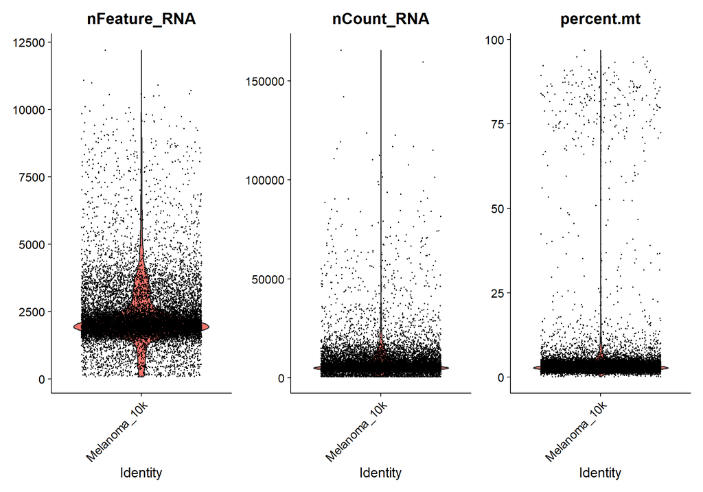

```r
mat <- Read10X(data.dir = "sample_filtered_feature_bc_matrix")
melanoma_raw <- CreateSeuratObject(counts = mat, project = "Melanoma_10k")
# QC visualization
melanoma_raw <- melanoma_raw |>
  PercentageFeatureSet(pattern = "^MT-", col.name = "percent.mt")

VlnPlot(melanoma_raw, features = c("nFeature_RNA", "nCount_RNA", "percent.mt"), ncol = 3)
```

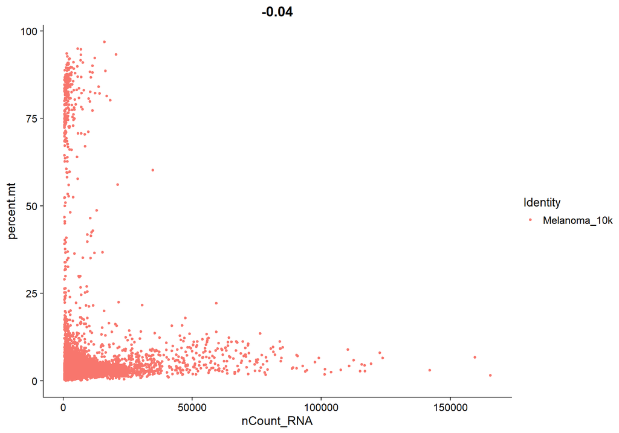

```r
FeatureScatter(melanoma_raw, feature1 = "nCount_RNA", feature2 = "percent.mt")
```

*Normalization and Feature Selection* Following the exclusion of low-quality cells, data normalization was performed using a global-scaling method (LogNormalize). To focus the analysis on biological variation, the top 2,000 highly variable features were identified using the variance-stabilizing transformation (vst) method. Subsequently, data scaling was executed to shift the mean expression to 0 and the variance to 1 for each gene.

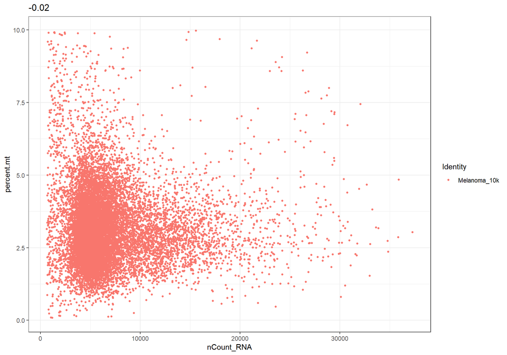

```r
if (!file.exists("processed_data/melanoma_normalized.rds")) {
melanoma <- melanoma_raw |>
  subset(subset = nFeature_RNA > 500 & nFeature_RNA < 6000 & percent.mt < 10) |>
  NormalizeData() |>
  FindVariableFeatures(selection.method = "vst", nfeatures = 2000) |>
  ScaleData()
saveRDS(melanoma, "processed_data/melanoma_normalized.rds")
} else {
  melanoma <- readRDS("processed_data/melanoma_normalized.rds")
}
melanoma |>
  FeatureScatter(feature1 = "nCount_RNA", feature2 = "percent.mt") +
  theme_bw()
```

To evaluate the technical quality of the sequencing run, key metrics were summarized. The high median gene count per cell and substantial sequencing depth suggest a high-complexity library suitable for resolving subtle cellular states.

```r
comparison_stats <- data.frame(
  Metric = c(
    "Estimated Number of Cells",
    "Median Genes per Cell",
    "Median UMI Counts per Cell",
    "Mean Mitochondrial Content (%)"
  ),
  Raw_Data = c(
    "12814",
    "2686",
    "11390",
    paste0(round(mean(melanoma_raw$percent.mt), 2), "%")
  ),
  Filtered_Data = c(
    as.character(ncol(melanoma)),
    as.character(round(median(melanoma$nFeature_RNA), 0)),
    as.character(round(median(melanoma$nCount_RNA), 0)),
    paste0(round(mean(melanoma$percent.mt), 2), "%")
  )
)

knitr::kable(
  comparison_stats,
  caption = "Technical Metrics Comparison (Raw vs. Filtered)",
  col.names = c("Metric", "Raw (10x Genomics Report)", "Filtered"),
  align = "lcc",
  format = "html",
  table.attr = 'class="table table-hover" style="width: 80%;"'
)
```

Technical Metrics Comparison (Raw vs. Filtered)

| Metric | Raw (10x Genomics Report) | Filtered |
| --- | --- | --- |
| Estimated Number of Cells | 12814 | 14451 |
| Median Genes per Cell | 2686 | 2067 |
| Median UMI Counts per Cell | 11390 | 5657 |
| Mean Mitochondrial Content (%) | 4.64% | 3.16% |

### Dimensionality Reduction

#### Linaar dimensionality reduction (PCA)

Linear dimensionality reduction was performed using Principal Component Analysis (PCA) to identify the primary axes of variation. To validate the biological relevance of the computed components, the top gene loadings were examined. PC1 and PC2 were predominantly driven by established melanoma markers and myeloid lineage genes.

Specifically: S100A1 and EDNRB (Endothelin Receptor B) showed high loadings, consistent with their role as markers of melanoma progression and overexpression in cutaneous malignancies [4,5]. Myeloid markers: TYROBP and CST3 (Cystatin C) contributed significantly to the variance, representing the infiltration of macrophages, monocytes, and dendritic cells within the tumor microenvironment [6].

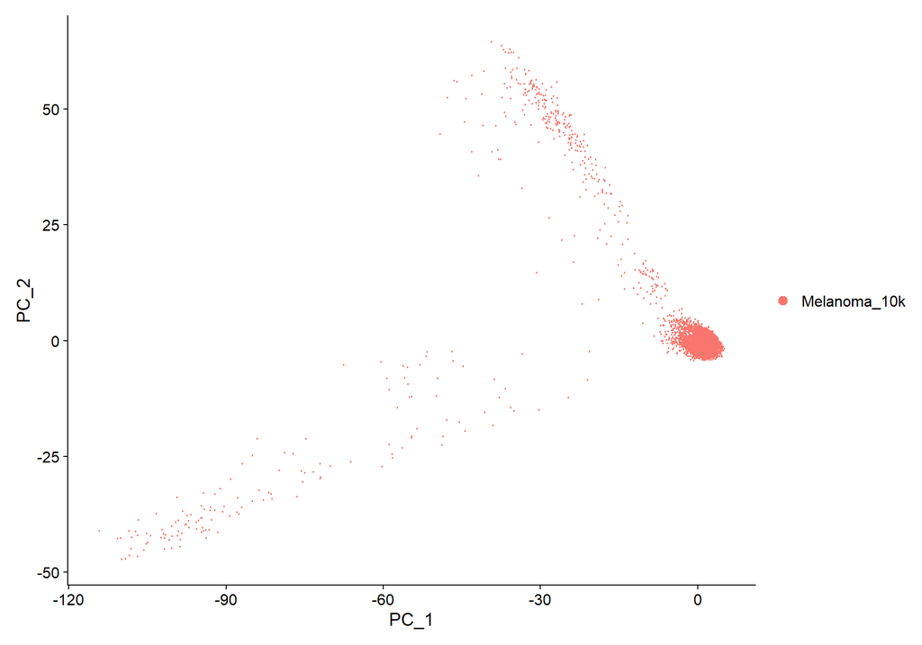

```r
melanoma <- RunPCA(melanoma)
DimPlot(melanoma)
```

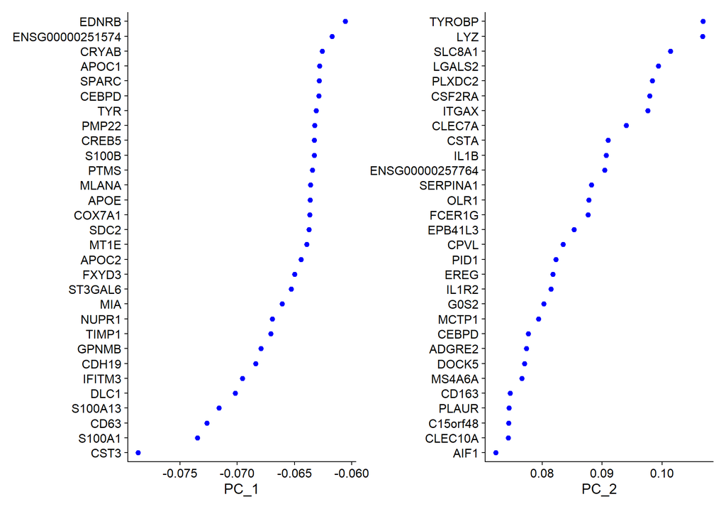

```r
VizDimLoadings(melanoma, dims = 1:2)
```

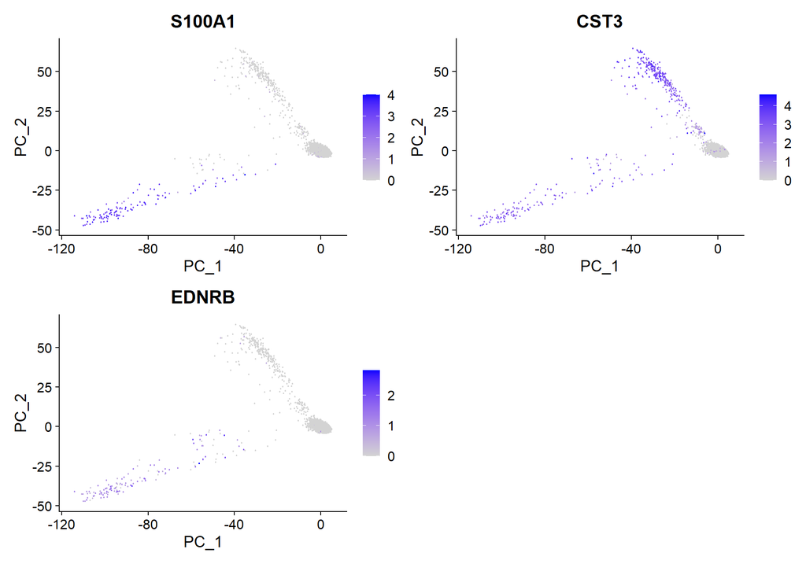

```r
FeaturePlot(melanoma, features = c("S100A1", "CST3", "EDNRB"))    # PC1
```

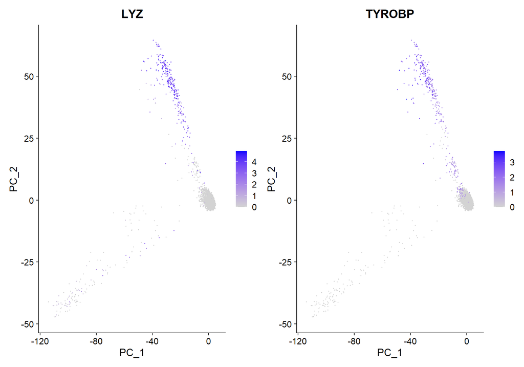

```r
FeaturePlot(melanoma, features = c("LYZ", "TYROBP"))              # PC2
```

#### Non-linear Dimensionality reduction (clasterization)

To determine the optimal number of Principal Components (PCs) for downstream non-linear dimensionality reduction, an Elbow plot was utilized. This heuristic identifies the point where additional components contribute minimally to the total variance - the first 25 PCs were selected. These components were subsequently used as input for graph-based clustering (resolution 0.5).

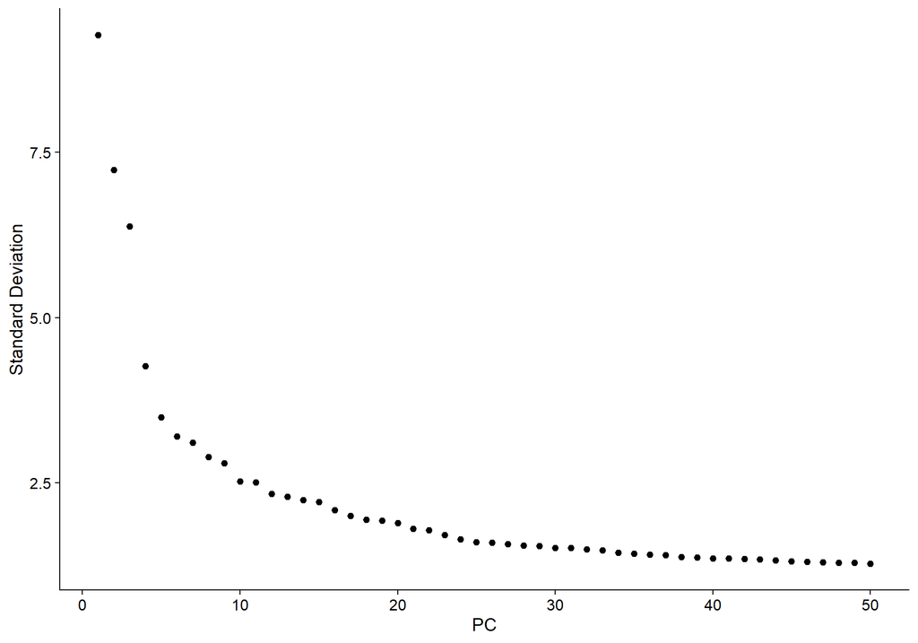

```r
ElbowPlot(melanoma, ndims = 50)
```

```r
if (!file.exists("processed_data/melanoma_clustered.rds")) {
melanoma <- melanoma |>
  FindNeighbors(dims = 1:25) |>
  FindClusters(resolution = 0.5) |>
  RunUMAP(dims = 1:25)
saveRDS(melanoma, "processed_data/melanoma_clustered.rds")
} else {
  # Завантажуємо об'єкт, де UMAP та кластери вже є
  melanoma <- readRDS("processed_data/melanoma_clustered.rds")
}
# Uncomment to see the unannotated clusters
#DimPlot(melanoma, reduction = "umap", label = TRUE) + NoLegend()
```

## Cell type annotation

To resolve the cellular composition of the melanoma microenvironment, a multi-step annotation strategy was employed, beginning with the validation of cluster-specific markers and canonical lineage genes

### Manual marker validation

The top 5 differentially expressed genes (DEGs) for each cluster were identified using the Wilcoxon test. These statistical markers serve as the primary evidence for cell-type assignment.

#### Cell markers table

```r
if (!file.exists("processed_data/melanoma_markers.rds")) {
melanoma.markers <- FindAllMarkers(melanoma,
                               only.pos = TRUE,
                               min.pct = 0.25,
                               logfc.threshold = 0.5)
saveRDS(melanoma.markers, "processed_data/melanoma_markers.rds")
} else {
melanoma.markers <- readRDS("processed_data/melanoma_markers.rds")
}
top5_markers <- melanoma.markers |>
  group_by(cluster) |>
  slice_max(n = 5, order_by = avg_log2FC) |>
  mutate(
    p_val = formatC(p_val, format = "e", digits = 2),
    p_val_adj = formatC(p_val_adj, format = "e", digits = 2),
    avg_log2FC = round(avg_log2FC, 2),
    pct.1 = round(pct.1, 3),
    pct.2 = round(pct.2, 3)
  )

DT::datatable(
  top5_markers,
  caption = "Top 5 Differentially expressed genes per cluster",
  options = list(pageLength = 10, scrollX = TRUE),
  rownames = FALSE
)
```

| p_val | avg_log2FC | pct.1 | pct.2 | p_val_adj | cluster | gene |
| --- | --- | --- | --- | --- | --- | --- |
| 0.00e+00 | 3.9 | 0.318 | 0.044 | 0.00e+00 | 0 | SYN3 |
| 0.00e+00 | 3.52 | 0.517 | 0.071 | 0.00e+00 | 0 | TCL1A |
| 0.00e+00 | 3.43 | 0.749 | 0.142 | 0.00e+00 | 0 | IGHD |
| 0.00e+00 | 3.42 | 0.554 | 0.111 | 0.00e+00 | 0 | GAB1 |
| 0.00e+00 | 3.3 | 0.306 | 0.059 | 0.00e+00 | 0 | NETO1 |
| 2.23e-235 | 2.96 | 0.265 | 0.054 | 8.59e-231 | 1 | ENSG00000249806 |
| 0.00e+00 | 2.75 | 0.426 | 0.101 | 0.00e+00 | 1 | GIMAP7 |
| 1.68e-246 | 2.71 | 0.318 | 0.076 | 6.50e-242 | 1 | GIMAP4 |
| 2.60e-264 | 2.67 | 0.311 | 0.066 | 1.00e-259 | 1 | CD40LG |
| 1.26e-197 | 2.56 | 0.279 | 0.07 | 4.86e-193 | 1 | LINC01550 |

[output cut: 55 more lines]

```r
# Look for "unique only/mostly" markers
pdf("Cluster_Markers_manual.pdf", width = 12, height = 8)
for(i in sort(unique(top5_markers$cluster))) {
  genes_to_plot <- top5_markers %>% filter(cluster == i) |> pull(gene)
  p1 <- FeaturePlot(melanoma, features = genes_to_plot, ncol = 3) +
    plot_annotation(title = paste("Top markers for Cluster", i))
  print(p1)
}
dev.off()
```

The spatial distribution maps for all candidate markers were exported to a dedicated supplement for detailed review: Exploratory FeaturePlots (PDF). These plots confirm the localized expression patterns.

#### Cell marker visualization

To validate lineage commitment, canonical markers for immune and malignant populations were visualized across all clusters.

```r
marker_list_melanoma <- list(
  'Neurons/tumor' = c("SYN3", "NETO1"),
  'T cells' = c("CD40LG"),
  'CTLA' = c("BTNL9", "CD80"),
  'Granulosa cells/pro-inflammatory' = c("ANKS1B", "ICA1", "TOX2"),
  'NK' = c("NKG7"),
  'Macrophages' = c("CD163"),
  'Plasma cells' = c("IGHG3", "IGHGP"),
  'Endothelial/melanocytes' = c("EDN3"))
marker_vln <- function(srt, marker_list, group_name) {
  genes <- marker_list[[group_name]]
  vln <- VlnPlot(srt, features = genes, ncol = length(genes), pt.size = 0) +
    patchwork::plot_annotation(title = group_name)
  return(vln)
}
vlnList <- lapply(names(marker_list_melanoma), marker_vln,
                  srt = melanoma, marker_list = marker_list_melanoma)
final_ga <- ggarrange(plotlist = vlnList, ncol = 1)
ggsave(final_ga, filename = "melanoma_validation_violins.png", height = 25, width = 15)
```

The consolidated visualization of lineage-specific expression is available for high-resolution analysis: Violin plots (PNG).

### Automated reference mapping

#### Findings & Consensus

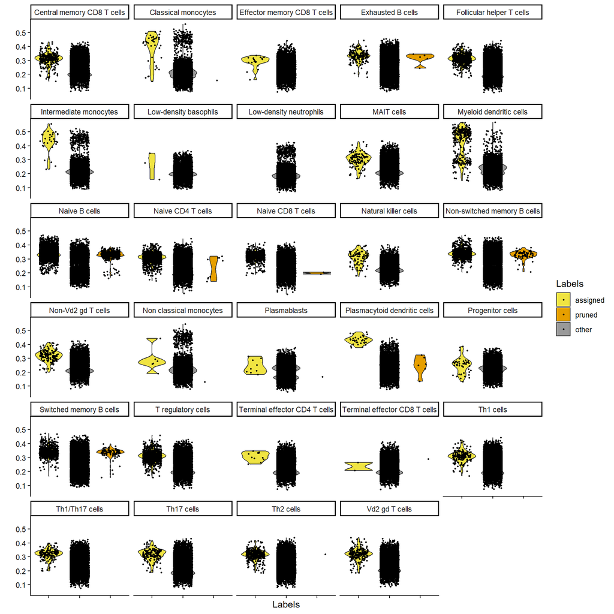

```r
# Predictions with different DBs
if (!file.exists("processed_data/singler_results.rds")) {

  bped.se <- BlueprintEncodeData()
  mimd.se <- MonacoImmuneData()
  sceP <- as.SingleCellExperiment(melanoma)
  pred.bped.main <- SingleR(test = sceP, ref = bped.se, labels = bped.se$label.main)
  pred.mimd.main <- SingleR(test = sceP, ref = mimd.se, labels = mimd.se$label.main)
  pred.mimd.fine <- SingleR(test = sceP, ref = mimd.se, labels = mimd.se$label.fine)
# Combine the IDs
  my_genes <- rownames(sceP)
  trained_mimd_main <- trainSingleR(mimd.se, labels = mimd.se$label.main, test.genes = my_genes)
  trained_mimd_fine <- trainSingleR(mimd.se, labels = mimd.se$label.fine, test.genes = my_genes)
  pred.comb <- combineRecomputedResults(
  results = list(Main = pred.mimd.main, Fine = pred.mimd.fine),
  test = sceP,
  trained = list(Main = trained_mimd_main, Fine = trained_mimd_fine),
  assay.type.test = "logcounts"
  )
  pred.mimd.fine$clusters <- melanoma$seurat_clusters

  saveRDS(list(
    bped = pred.bped.main,
    mimd_main = pred.mimd.main,
    mimd_fine = pred.mimd.fine,
    comb = pred.comb
  ), "processed_data/singler_results.rds")

} else {
  singler_res <- readRDS("processed_data/singler_results.rds")
  pred.bped.main <- singler_res$bped
  pred.mimd.main <- singler_res$mimd_main
  pred.mimd.fine <- singler_res$mimd_fine
  pred.comb      <- singler_res$comb
}

melanoma$predicted_id <- pred.comb$pruned.labels

plotScoreDistribution(pred.mimd.fine)
```

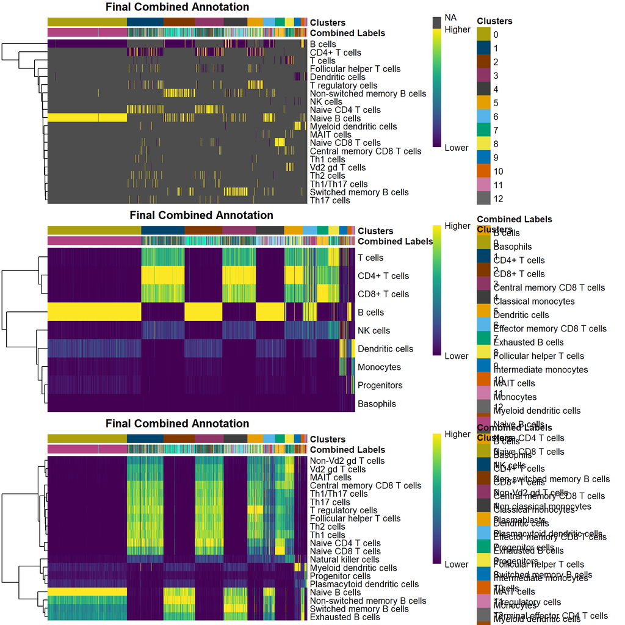

```r
plotScoreHeatmap(pred.comb,
                 max.labels = 20,
                 clusters = melanoma$seurat_clusters,
                 order.by = "clusters",
                 show_colnames = FALSE,
                 main = "Final Combined Annotation")
```

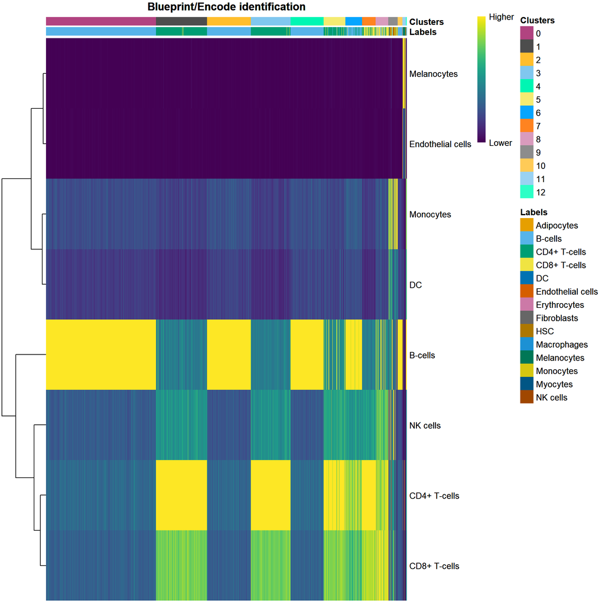

```r
# Technical supplements
pdf("Cluster_Markers_auto.pdf", height = 10)

print(plotScoreHeatmap(pred.bped.main,
                 max.labels = 8,
                 clusters = melanoma$seurat_clusters,
                 order.by = "clusters",
                 show_colnames = FALSE,
                 main = "Blueprint/Encode identification"))
```

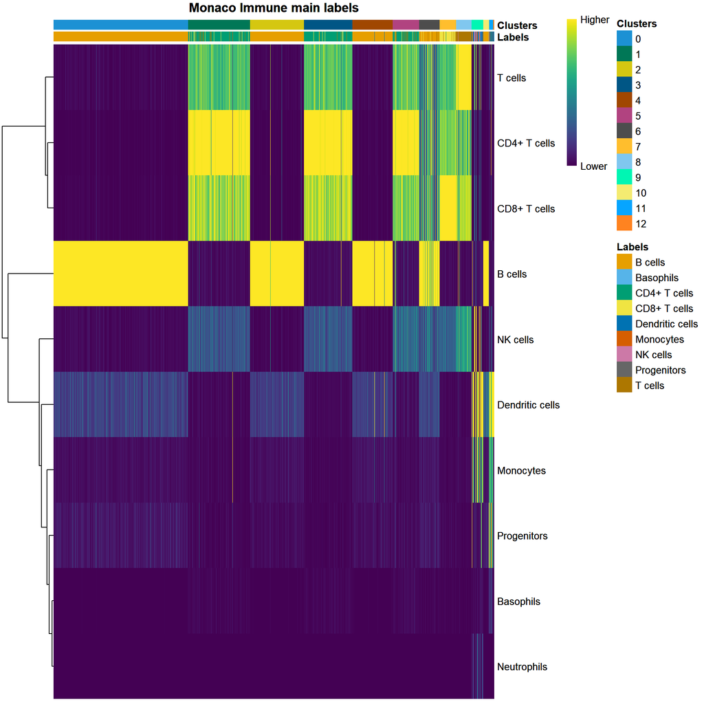

```r
print(plotScoreHeatmap(pred.mimd.main,
                 max.labels = 20,
                 clusters = melanoma$seurat_clusters,
                 order.by = "clusters",
                 show_colnames = FALSE,
                 main = "Monaco Immune main labels"))
```

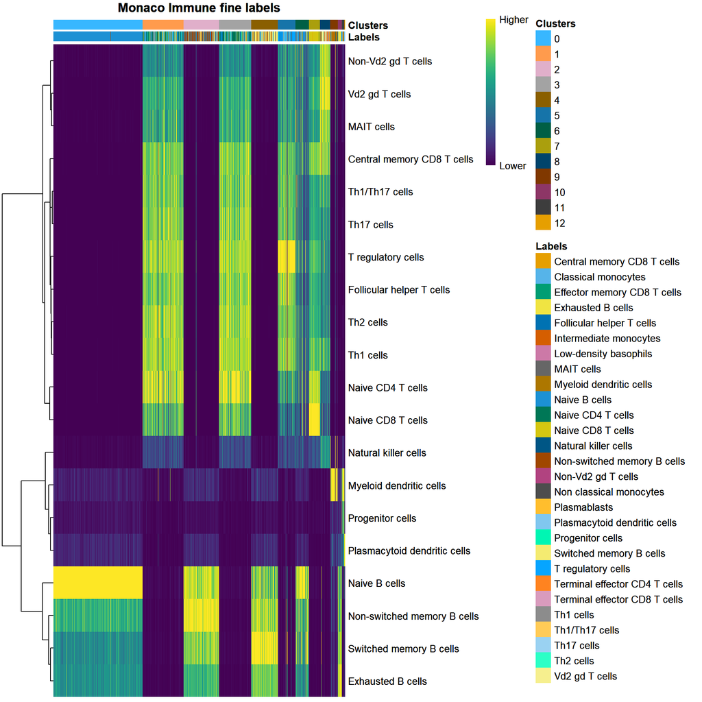

```r
print(plotScoreHeatmap(pred.mimd.fine,
                 max.labels = 20,
                 clusters = melanoma$seurat_clusters,
                 order.by = "clusters",
                 show_colnames = FALSE,
                 main = "Monaco Immune fine labels"))
```

```r
dev.off()
```

Detailed results of identifictaion are available for download Cluster markers heatmaps (PDF)

#### Cluster-Identity Table

```r
conf_table <- table(melanoma$predicted_id, melanoma$seurat_clusters)
DT::datatable(
  as.data.frame.matrix(conf_table),
  caption = "Table 3: Seurat Clusters vs. SingleR predicted IDs",
  options = list(pageLength = 35, scrollX = TRUE)
)
```

|  | 0 | 1 | 2 | 3 | 4 | 5 | 6 | 7 | 8 | 9 | 10 | 11 | 12 |
| --- | --- | --- | --- | --- | --- | --- | --- | --- | --- | --- | --- | --- | --- |
| B cells | 3 | 0 | 66 | 0 | 148 | 2 | 10 | 0 | 0 | 0 | 70 | 0 | 0 |
| Basophils | 0 | 0 | 0 | 0 | 0 | 0 | 0 | 0 | 0 | 2 | 0 | 0 | 0 |
| CD4+ T cells | 0 | 347 | 0 | 284 | 0 | 62 | 4 | 0 | 1 | 1 | 0 | 1 | 0 |
| CD8+ T cells | 0 | 6 | 0 | 6 | 0 | 2 | 1 | 20 | 3 | 0 | 0 | 0 | 0 |
| Central memory CD8 T cells | 0 | 60 | 0 | 39 | 0 | 12 | 1 | 19 | 104 | 0 | 1 | 0 | 0 |
| Classical monocytes | 0 | 0 | 0 | 0 | 0 | 0 | 0 | 0 | 0 | 18 | 0 | 5 | 0 |
| Dendritic cells | 0 | 1 | 0 | 0 | 0 | 0 | 0 | 0 | 0 | 7 | 1 | 47 | 0 |
| Effector memory CD8 T cells | 0 | 1 | 0 | 0 | 0 | 0 | 0 | 0 | 15 | 0 | 0 | 0 | 0 |
| Exhausted B cells | 0 | 0 | 0 | 0 | 0 | 0 | 0 | 0 | 0 | 0 | 6 | 0 | 0 |
| Follicular helper T cells | 0 | 133 | 0 | 83 | 0 | 140 | 0 | 0 | 1 | 0 | 0 | 0 | 0 |

[output cut: 25 more lines]

From this perspective it is quite clear that cluster 11 contains melanocytes (tumor) and all other clusters are the immune microenvironment.

### Spatial organization

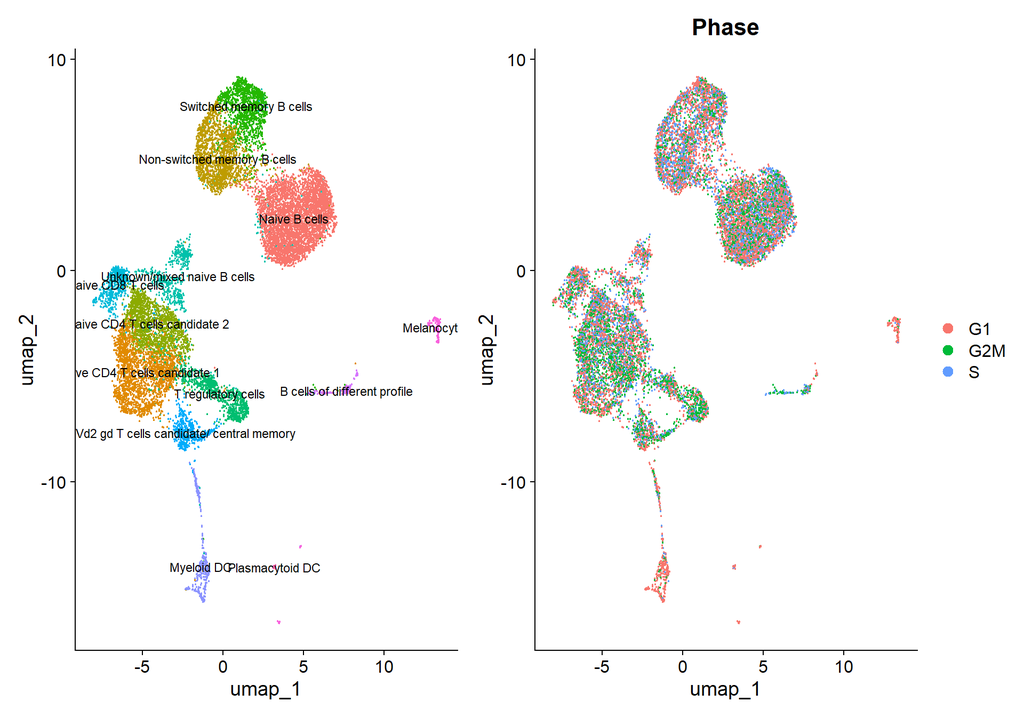

```r
Idents(melanoma) <- melanoma$seurat_clusters
initial_ids <- c(
  "0" = "Naive B cells",
  "1" = "Naive CD4 T cells candidate 1",
  "2" = "Non-switched memory B cells",
  "3" = "Naive CD4 T cells candidate 2",
  "4" = "Switched memory B cells",
  "5" = "T regulatory cells",
  "6" = "Unknown/mixed naive B cells",
  "7" = "Naive CD8 T cells",
  "8" = "Vd2 gd T cells candidate/ central memory",
  "9" = "Myeloid DC",
  "10" = "B cells of different profile",
  "11" = "Melanocytes",
  "12" = "Plasmacytoid DC"
)
melanoma <- RenameIdents(melanoma, initial_ids)
melanoma$cell_type <- Idents(melanoma)
# Cell cycle analysis
s.genes <- cc.genes.updated.2019$s.genes
g2m.genes <- cc.genes.updated.2019$g2m.genes

melanoma_cycle <- CellCycleScoring(melanoma,
                             s.features = s.genes,
                             g2m.features = g2m.genes,
                             set.ident = TRUE)

p1_init <- DimPlot(melanoma, reduction = "umap", label.size = 3, label = TRUE) + NoLegend()
p2_init <- DimPlot(melanoma_cycle,  group.by = "Phase")
p1_init + p2_init
```

The T-cell, B-cell, and dendritic cell populations are clearly distinct, with the melanocyte cluster also forming a separate group. One specific B-cell cluster is particularly noteworthy as it is positioned away from the others; it expresses a set of exhausted B-cell markers absent in other clusters, potentially indicating a hidden communication axis with the melanoma. Fully identifying sub-populations remains challenging because this map captures a ‘dynamic cell transformation’ process. As markers gradually appear and disappear, a ‘pseudotime’ or trajectory analysis is required to resolve these transitions.

1. Clusters are defined by cell type, not cycle artifacts.
2. Tumor cells are predominantly in G1, indicating a quiescent state at sampling.
3. The distinct B-cell* cluster suggests a specific functional activation separate from naive/memory pools.

### Cellular dynamics and states

#### Continuum analysis

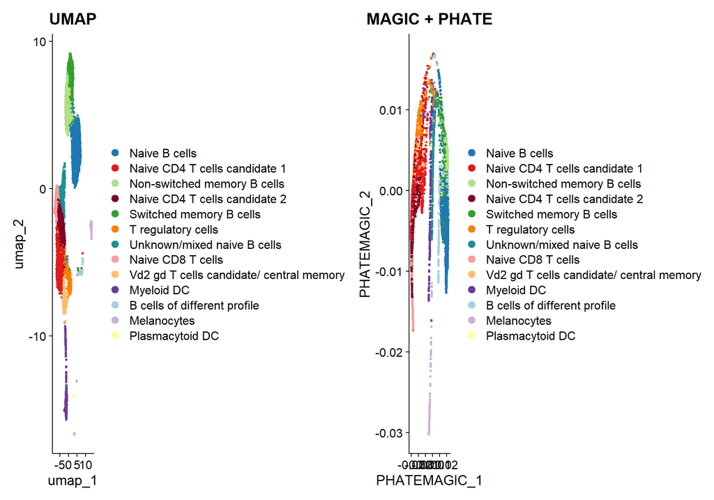

```r
if (!file.exists("processed_data/phate_magic_embeddings.rds")) {
input_data_t <- t(LayerData(melanoma, assay = "RNA", layer = "data"))

data_MAGIC <- magic(input_data_t, knn = 15, seed = 42)
phate_res <- phate(data_MAGIC, knn = 20, t = "auto")
phate_embeddings_raw <- as.matrix(phate_res$embedding)
rownames(phate_embeddings_raw) <- rownames(input_data_t)
final_mat <- matrix(NA, nrow = ncol(melanoma), ncol = 2)
rownames(final_mat) <- colnames(melanoma)
colnames(final_mat) <- c("PHATEMAGIC_1", "PHATEMAGIC_2")
common <- intersect(rownames(final_mat), rownames(phate_embeddings_raw))
final_mat[common, ] <- phate_embeddings_raw[common, ]

saveRDS(final_mat, "processed_data/phate_magic_embeddings.rds")
} else {
  final_mat <- readRDS("processed_data/phate_magic_embeddings.rds")
}
melanoma[["phate_magic"]] <- CreateDimReducObject(
  embeddings = final_mat,
  key = "PHATEMAGIC_",
  assay = "RNA"
)
my_cols <- c(
  "Naive B cells" = "#1F78B4",
  "B cells of different profile" = "#A6CEE3",
  "Switched memory B cells" = "#33A02C",
  "Non-switched memory B cells" = "#B2DF8A",
  "Unknown/mixed naive B cells" = "#1c9099",
  "Naive CD4 T cells candidate 1" = "#E31A1C",
  "Naive CD4 T cells candidate 2" = "#800026",
  "Naive CD8 T cells" = "#FB9A99",
  "T regulatory cells" = "#FF7F00",
  "Vd2 gd T cells candidate/ central memory" = "#FDBF6F",
  "Melanocytes" = "#CAB2D6",
  "Myeloid DC" = "#6A3D9A",
  "Plasmacytoid DC" = "#FFFF99"
)

p2 <- DimPlot(melanoma, reduction = "umap", group.by = "cell_type", cols = my_cols, pt.size = 0.6) + labs(title = "UMAP")
p3 <- DimPlot(melanoma, reduction = "phate_magic", group.by = "cell_type", cols = my_cols, pt.size = 0.6) + labs(title = "MAGIC + PHATE")

p2 + p3
```

#### Lineage trajectories

```r
if (!file.exists("processed_data/cell_cycle_cds.rds")) {
cds <- as.cell_data_set(melanoma)
cds <- cluster_cells(cds, reduction_method = "UMAP")
cds <- learn_graph(cds, use_partition = TRUE)

cell_partitions <- partitions(cds)
unique_parts <- unique(cell_partitions)
all_root_cells <- c()

for (p in unique_parts) {
  idx <- which(cell_partitions == p)[1]
  cell_name <- names(cell_partitions)[idx]
  all_root_cells <- c(all_root_cells, cell_name)
}

cds <- order_cells(cds,
                   reduction_method = "UMAP",
                   root_cells = all_root_cells)
saveRDS(cds, "processed_data/cell_cycle_cds.rds")
} else {
  cds <- readRDS("processed_data/cell_cycle_cds.rds")
}
```

[output not shown]

[output not shown]

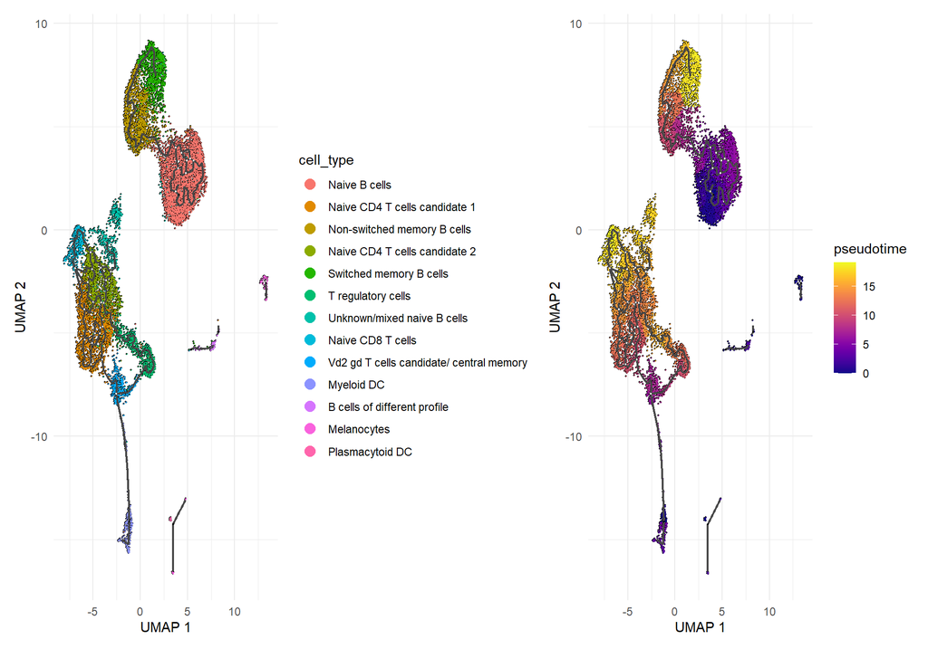

```r
colData(cds)$cell_type <- melanoma$cell_type

p4 <- plot_cells(cds,
                 color_cells_by = "cell_type",
                 label_cell_groups = FALSE,
                 label_leaves = FALSE,
                 graph_label_size = 0) +
  theme_minimal()

p5 <- plot_cells(cds,
                 color_cells_by = "pseudotime",
                 label_cell_groups = FALSE,
                 label_leaves = FALSE,
                 graph_label_size = 0) +
  theme_minimal()

p4 + p5
```

#### Metabolic cell states

The consolidated visualization of activated metabolic pathways is available for high-resolution analysis: Cluster metabolism (PDF)

```r
if (!file.exists("All_Clusters_Enrichr_Report.pdf")) {
sig_markers <- melanoma.markers |>  filter(p_val_adj < 0.05)

to_check <- c("Human_Gene_Atlas", "ENCODE_and_ChEA_Consensus_TFs_from_ChIP-X",
              "KEGG_2019_Human", "MSigDB_Hallmark_2020")

pdf("All_Clusters_Enrichr_Report.pdf", width = 16, height = 10)

for (target_cluster in sort(unique(sig_markers$cluster))) {

  cl_genes <- sig_markers |>
    filter(cluster == target_cluster) |>
    pull(gene)

  if(length(cl_genes) == 0) next

  cl_eres <- enrichr(cl_genes, databases = to_check)

  plotList <- lapply(names(cl_eres), function(db) {
    df <- cl_eres[[db]]
    if (is.null(df) || nrow(df) == 0) return(NULL)

    df |>
      top_n(10, wt = -log10(Adjusted.P.value)) |>
      mutate(Term = stringr::str_trunc(Term, 45)) |>
      mutate(Term = factor(Term, levels = rev(unique(Term)))) |>
      ggplot(aes(x = Term, y = -log10(Adjusted.P.value), fill = Combined.Score)) +
      geom_col() +
      coord_flip() +
      theme_minimal(base_size = 12) +
      labs(title = db, x = "") +
      scale_fill_gradient(low = "skyblue", high = "darkblue")
  })

  plotList <- Filter(Negate(is.null), plotList)

  if(length(plotList) > 0) {
    combined_plot <- cowplot::plot_grid(plotlist = plotList, labels = "AUTO", ncol = 2) +
      patchwork::plot_annotation(
        title = paste("Cluster", target_cluster, "Enrichr Analysis"),
        theme = theme(plot.title = element_text(size = 20, face = "bold", hjust = 0.5))
      )
    print(combined_plot)
  }
}
dev.off()
}
```

Key Findings:

Cluster 1 vs 3. Although both clusters are CD4+ T-cells, they are separated by their activation level and biological “mission”: cluster 1 cells are in a state of acute inflammation. A very strong TNF-alpha signaling score (over 20 on the -log_10P scale). Cluster 3 cells are also in the tumor area, but they are receiving “calming” or regulatory signals: the TNF-alpha signal is weaker (around 15), and unique pathways like IL-6/STAT3 and IL-2/STAT5 appear.

Cluster 6 (Ambiguous B cells): Likely some B-T cell doublets. It lacks a strong B-cell metabolic signature and sits “physically” between B and T islands on the UMAP, suggesting a mixed transcriptional signal.

Cluster 10 (Plasma B cells): A distinct functional lineage. The extreme shift on the UMAP is driven by a metabolic explosion: massive Proteasome activity and Oxidative phosphorylation required for high-intensity antibody production.

Cluster 8 represents a specialized population of Vd2 gd T-cells and memory CD8+ T-cells that exhibit a hybrid NK-like transcriptional profile and a high readiness for rapid anti-tumor response, as evidenced by the strong enrichment of T-cell receptor signaling and TNF-alpha inflammatory pathways.

Summary: The clustering is driven by functional shifts (exhaustion, inflammation, and protein secretion) rather than just cell lineage.

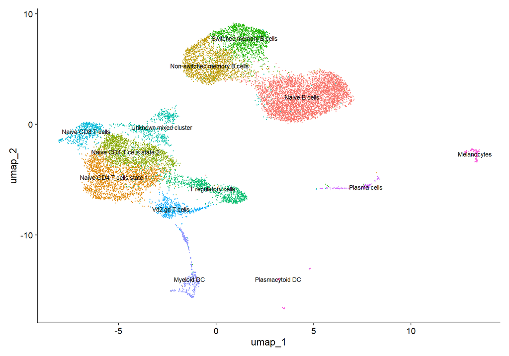

```r
Idents(melanoma) <- melanoma$seurat_clusters
final_ids <- c(
  "0" = "Naive B cells",
  "1" = "Naive CD4 T cells state 1",
  "2" = "Non-switched memory B cells",
  "3" = "Naive CD4 T cells state 2",
  "4" = "Switched memory B cells",
  "5" = "T regulatory cells",
  "6" = "Unknown mixed cluster",
  "7" = "Naive CD8 T cells",
  "8" = "Vd2 gd T cells",
  "9" = "Myeloid DC",
  "10" = "Plasma cells",
  "11" = "Melanocytes",
  "12" = "Plasmacytoid DC"
)
melanoma <- RenameIdents(melanoma, final_ids)
melanoma$cell_type <- Idents(melanoma)
DimPlot(melanoma, reduction = "umap", label.size = 3, label = TRUE) + NoLegend()
```

### Tumor microenvironment signaling

#### Global patterns

```r
if (!file.exists("processed_data/cellchat.rds")) {
cellchat <- createCellChat(object = GetAssayData(melanoma, assay = "RNA", layer = "data"),
                           meta = melanoma@meta.data,
                           group.by = "cell_type")

cellchat@DB <- CellChatDB.human

cellchat <- cellchat |>
  subsetData() |>
  identifyOverExpressedGenes() |>
  identifyOverExpressedInteractions() |>
  computeCommunProb(type = "triMean") |>
  filterCommunication(min.cells = 10) |>
  computeCommunProbPathway() |>
  aggregateNet() |>
  netAnalysis_computeCentrality(slot.name = "netP")

saveRDS(cellchat, "processed_data/cellchat.rds")
} else {
  cellchat <- readRDS("processed_data/cellchat.rds")
}

pdf("Signaling_Heatmap.pdf", width = 8, height = 10)
p6 <- netAnalysis_signalingRole_heatmap(cellchat,
                                  pattern = "outgoing",
                                  width = 10,
                                  height = 10,
                                  font.size = 8)
print(p6)
p7 <- netAnalysis_signalingRole_heatmap(cellchat,
                                  pattern = "incoming",
                                  width = 10,
                                  height = 10,
                                 font.size = 8)
print(p7)
dev.off()
```

```r
p6 + p7
```

[output not shown]

Open file in new window

#### Immune communication axis

##### Source table

```r
rank.df <- data.frame(score = apply(cellchat@netP$prob, 3, sum)) |>
  (\(df) df[order(df$score, decreasing = TRUE), , drop = FALSE])()|>
  slice_max(n = 15, order_by = score)
knitr::kable(
  rank.df,
  caption = "Table 4: Top signaling pathways of microenvironment",
  col.names = c("Signaling pathway", "Score"),
  align = "lcc",
  format = "html",
  table.attr = 'class="table table-hover" style="width: 80%;"'
)
```

Table 4: Top signaling pathways of microenvironment

| Signaling pathway | Score |
| --- | --- |
| MIF | 19.694839 |
| MHC-I | 17.860699 |
| ADGRE5 | 11.603325 |
| APP | 6.124109 |
| CD45 | 4.024570 |
| CD22 | 3.864832 |
| MHC-II | 3.525374 |
| CD99 | 2.158522 |
| TGFb | 1.885242 |
| LAMININ | 1.433982 |
| MK | 1.383678 |
| SPP1 | 1.352834 |
| ALCAM | 1.318365 |
| CD6 | 1.318365 |
| VISFATIN | 1.264606 |

##### Chord diagram

```r
pdf("chord_all_cells.pdf")
imm_paths_all <- intersect(c("MIF", "MHC-I", "ADGRE5"), cellchat@netP$pathways)
p8 <- netVisual_chord_gene(cellchat, signaling = imm_paths_all,
                     slot.name = "netP",
                     thresh = 0.1,
                     lab.cex = 0.7,
                     small.gap = 2)
print(p8)
dev.off()
```

```r
p8 <- netVisual_chord_gene(cellchat, signaling = imm_paths_all,
                     slot.name = "netP",
                     thresh = 0.1,
                     lab.cex = 0.7,
                     small.gap = 2)
p8
```

[output not shown]

Open file in new window

#### Melanoma communication axis

##### Sorce table

```r
melanoma.rank <- subsetCommunication(cellchat, sources.use = "Melanocytes") |>
  aggregate(prob ~ pathway_name, data = _, sum) |>
  (\(df) df[order(df$prob, decreasing = TRUE), ])()
knitr::kable(
  melanoma.rank,
  caption = "Table 4: Top signaling pathways of melanoma",
  col.names = c("Signaling pathway", "Score"),
  align = "lcc",
  format = "html",
  table.attr = 'class="table table-hover" style="width: 80%;"'
)
```

Table 4: Top signaling pathways of melanoma

|  | Signaling pathway | Score |
| --- | --- | --- |
| 25 | MIF | 4.9668540 |
| 3 | APP | 2.0766621 |
| 21 | LAMININ | 1.4339819 |
| 26 | MK | 1.3836778 |
| 38 | SPP1 | 1.3528338 |
| 23 | MHC-I | 0.9351016 |
| 8 | CD99 | 0.4690781 |
| 41 | THBS | 0.4182354 |
| 11 | COLLAGEN | 0.2559049 |
| 16 | GDF | 0.2404264 |
| 44 | VISFATIN | 0.1575896 |
| 19 | ICAM | 0.0909856 |
| 24 | MHC-II | 0.0460369 |
| 5 | CADM | 0.0329056 |
| 17 | GRN | 0.0322480 |
| 32 | PSAP | 0.0302471 |
| 28 | NECTIN | 0.0294861 |
| 20 | JAM | 0.0234249 |
| 1 | ANGPTL | 0.0232937 |
| 15 | FGF | 0.0231272 |
| 4 | BAFF | 0.0221676 |
| 40 | TGFb | 0.0206743 |
| 2 | ANNEXIN | 0.0206595 |
| 14 | EPHA | 0.0154598 |
| 34 | SEMA3 | 0.0149100 |
| 6 | CALCR | 0.0119632 |
| 43 | VEGF | 0.0112488 |
| 12 | CSPG4 | 0.0100073 |
| 10 | CLDN | 0.0082584 |
| 7 | CD137 | 0.0076756 |
| 35 | SEMA4 | 0.0055772 |
| 37 | SEMA7 | 0.0054842 |
| 33 | PTPRM | 0.0051292 |
| 31 | PROS | 0.0041191 |
| 30 | NRXN | 0.0038775 |
| 36 | SEMA5 | 0.0037374 |
| 13 | EDN | 0.0032216 |
| 9 | CDH | 0.0020486 |
| 29 | NEGR | 0.0020185 |
| 18 | HSPG | 0.0015498 |
| 39 | TENASCIN | 0.0015282 |
| 22 | LIFR | 0.0014059 |
| 42 | TWEAK | 0.0007801 |
| 27 | MPZ | 0.0004174 |

##### Chord Diagram

```r
pdf("chord_melanoma.pdf")
imm_paths_mel <- intersect(c("MIF", "APP", "LAMININ", "MK", "SPP1", "MHC-I", "CD99"), cellchat@netP$pathways)
p9 <- netVisual_chord_gene(cellchat, signaling = imm_paths_mel,
                     slot.name = "netP",
                     sources.use = "Melanocytes",
                     thresh = 0.1,
                     lab.cex = 0.7)
print(p9)
dev.off()
```

```r
p9 <- netVisual_chord_gene(cellchat, signaling = imm_paths_mel,
                     slot.name = "netP",
                     sources.use = "Melanocytes",
                     thresh = 0.1,
                     lab.cex = 0.7)
p9
```

[output not shown]

Open file in new window

### References:

1. Tasdogan, A., Sullivan, R., Katalinic, A., Lebbé, C., Whitaker, D., Puig, S., Van De Poll-Franse, L., Massi, D., & Schadendorf, D. (2025). Cutaneous melanoma. Nature Reviews Disease Primers, 11. https://doi.org/10.1038/s41572-025-00603-8.
2. Hossain, S., & Eccles, M. (2023). Phenotype Switching and the Melanoma Microenvironment; Impact on Immunotherapy and Drug Resistance. International Journal of Molecular Sciences, 24. https://doi.org/10.3390/ijms24021601.
3. Sikorski, H., Żmijewski, M., & Piotrowska, A. (2025). Tumor Microenvironment in Melanoma—Characteristic and Clinical Implications. International Journal of Molecular Sciences, 26. https://doi.org/10.3390/ijms26146778.
4. Lahav, R., Suvà, M. L., Rimoldi, D., Patterson, P. H., & Stamenkovic, I. (2004). Endothelin receptor B inhibition triggers apoptosis and enhances angiogenesis in melanomas. Cancer research, 64(24), 8945–8953. https://doi.org/10.1158/0008-5472.CAN-04-1510
5. Xiong, T. F., Pan, F. Q., & Li, D. (2019). Expression and clinical significance of S100 family genes in patients with melanoma. Melanoma research, 29(1), 23–29. https://doi.org/10.1097/CMR.0000000000000512
6. TYROBP protein expression summary - The Human Protein Atlas. URL:https://www.proteinatlas.org/ENSG00000011600-TYROBP. Accessed: 2026-04-07